# CodeBook del proyecto - Análisis de la Informalidad Laboral utilizando datos de la ENAHO 2025

Autogenerated data summary from dataMaid

2026-07-02 20:14:59.686019

# Data report overview

The dataset examined has the following dimensions:

| Feature | Result |
| --- | --- |
| Number of observations | 51164 |
| Number of variables | 14 |

### Checks performed

The following variable checks were performed, depending on the data type of each variable:

|  | character | factor | labelled | haven labelled | numeric | integer | logical | Date |
| --- | --- | --- | --- | --- | --- | --- | --- | --- |
| Identify miscoded missing values | × | × | × | × | × | × |  | × |
| Identify prefixed and suffixed whitespace | × | × | × | × |  |  |  |  |
| Identify levels with < 6 obs. | × | × | × | × |  |  |  |  |
| Identify case issues | × | × | × | × |  |  |  |  |
| Identify misclassified numeric or integer variables | × | × | × | × |  |  |  |  |
| Identify outliers |  |  |  |  | × | × |  | × |

Please note that all numerical values in the following have been rounded to 2 decimals.

# Summary table

|  | Variable class | # unique values | Missing observations | Any problems? |
| --- | --- | --- | --- | --- |
| edad | numeric | 82 | 0.00 % |  |
| sexo | factor | 2 | 0.00 % |  |
| tiene_ruc_etiqueta | factor | 4 | 11.46 % |  |
| categoria_ocupacional_etiqueta | factor | 7 | 0.00 % |  |
| tipo_contrato_etiqueta | factor | 8 | 47.00 % |  |
| formalidad_sector | factor | 3 | 11.46 % |  |
| formalidad_empleo | factor | 3 | 0.45 % |  |
| grupo_edad_teoria | factor | 4 | 0.00 % |  |
| quintil_ingreso | integer | 5 | 0.00 % |  |
| afiliacion_salud | factor | 2 | 0.00 % |  |
| afiliacion_pensiones | factor | 3 | 0.00 % |  |
| indice_confianza_simple | numeric | 352 | 0.37 % | × |
| ingreso_prin_imputado | numeric | 1141 | 0.00 % | × |
| tipologia_laboral | factor | 5 | 11.46 % |  |

# Variable list

## edad

*Edad del encuestado (Fuente: P208A)*

| Feature | Result |
| --- | --- |
| Variable type | numeric |
| Number of missing obs. | 0 (0 %) |
| Number of unique values | 82 |
| Median | 45 |
| 1st and 3rd quartiles | 33; 58 |
| Min. and max. | 17; 98 |

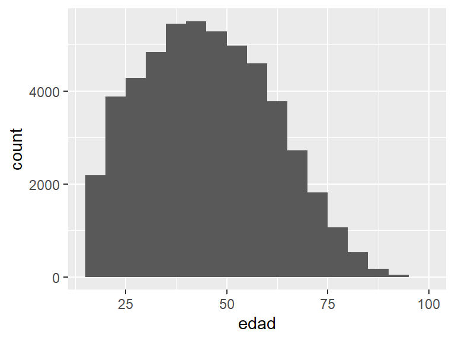

## sexo

*Sexo del encuestado (Fuente: P207)*

| Feature | Result |
| --- | --- |
| Variable type | factor |
| Number of missing obs. | 0 (0 %) |
| Number of unique values | 2 |
| Mode | “Hombre” |
| Reference category | Hombre |

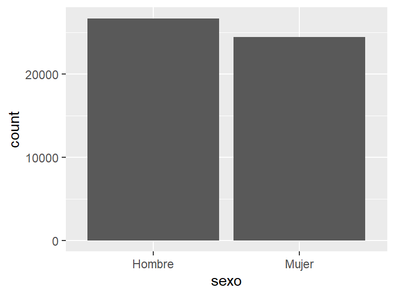

## tiene_ruc_etiqueta

*Registro en SUNAT del centro de trabajo (Fuente: P510A1)*

| Feature | Result |
| --- | --- |
| Variable type | factor |
| Number of missing obs. | 5864 (11.46 %) |
| Number of unique values | 3 |
| Mode | “No tiene RUC” |
| Reference category | Persona Jurídica |

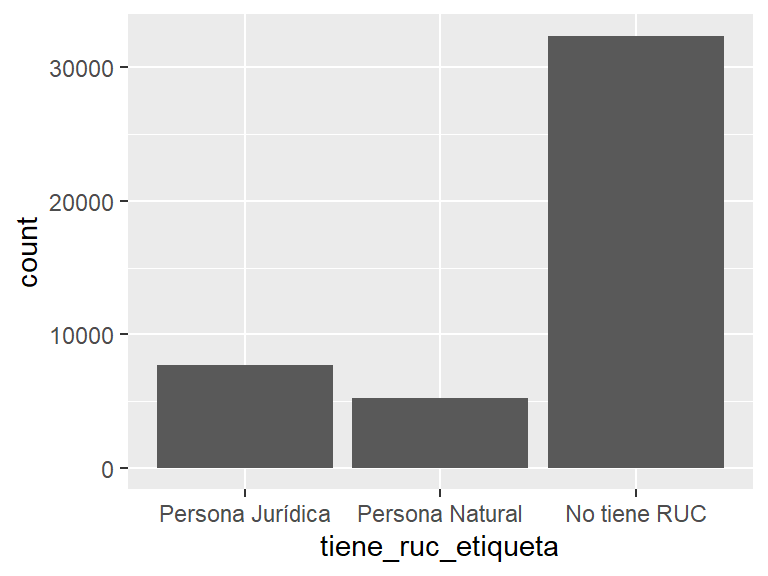

## categoria_ocupacional_etiqueta

*Categoría Ocupacional Principal (Fuente: P507)*

| Feature | Result |
| --- | --- |
| Variable type | factor |
| Number of missing obs. | 0 (0 %) |
| Number of unique values | 7 |
| Mode | “Trabajador independiente” |
| Reference category | Empleador o patrono |

[figure not shown]

## tipo_contrato_etiqueta

*Tipo de Contrato Laboral (Fuente: P511A)*

| Feature | Result |
| --- | --- |
| Variable type | factor |
| Number of missing obs. | 24047 (47 %) |
| Number of unique values | 7 |
| Mode | “Sin contrato” |
| Reference category | A plazo indefinido |

[figure not shown]

## formalidad_sector

*Formalidad del Centro de Empleo*

| Feature | Result |
| --- | --- |
| Variable type | factor |
| Number of missing obs. | 5864 (11.46 %) |
| Number of unique values | 2 |
| Mode | “Sector Informal” |
| Reference category | Sector Formal |

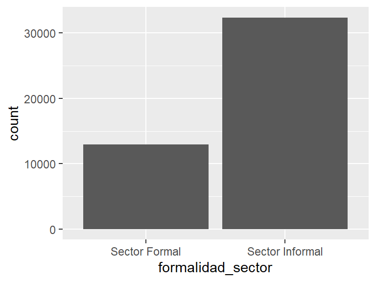

## formalidad_empleo

*Formalidad laboral*

| Feature | Result |
| --- | --- |
| Variable type | factor |
| Number of missing obs. | 231 (0.45 %) |
| Number of unique values | 2 |
| Mode | “Empleo Informal” |
| Reference category | Empleo Formal |

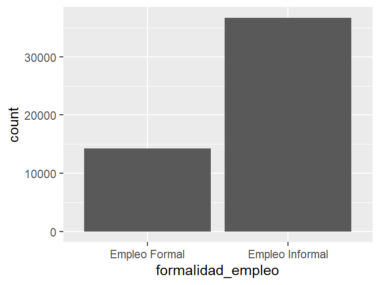

## grupo_edad_teoria

*Grupo de Edad (Cortes segúm metodología INEI)*

| Feature | Result |
| --- | --- |
| Variable type | factor |
| Number of missing obs. | 0 (0 %) |
| Number of unique values | 4 |
| Mode | “30 a 44 años” |
| Reference category | 18 a 29 años |

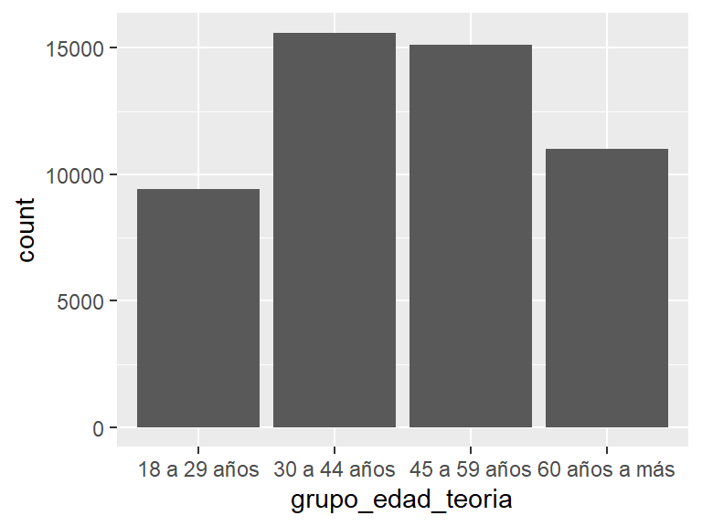

## quintil_ingreso

*Quintil de Ingresos (a partir de ingreso_prin_imputado)*

- Note that this variable is treated as a factor variable below, as it only takes a few unique values.

| Feature | Result |
| --- | --- |
| Variable type | integer |
| Number of missing obs. | 0 (0 %) |
| Number of unique values | 5 |
| Mode | “1” |
| Reference category | 1 |

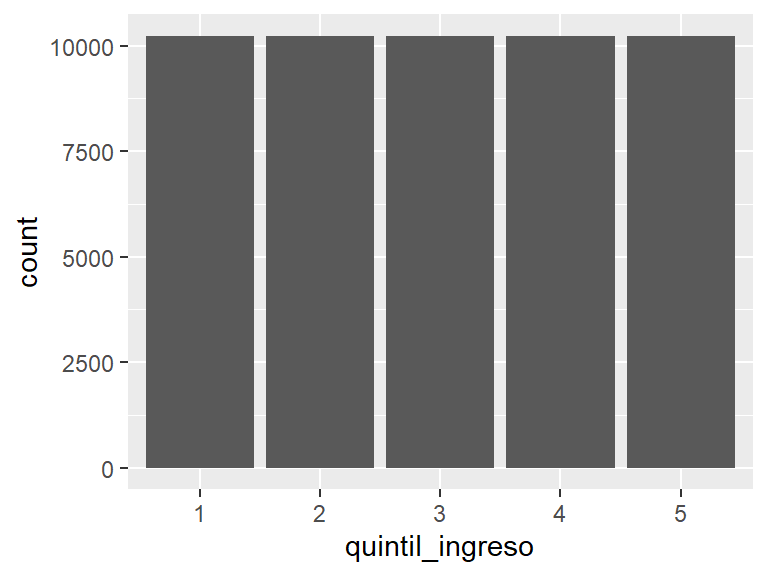

## afiliacion_salud

*Condición de afiliación al sistema de salud*

| Feature | Result |
| --- | --- |
| Variable type | factor |
| Number of missing obs. | 0 (0 %) |
| Number of unique values | 2 |
| Mode | “Afiliado a salud” |
| Reference category | Afiliado a salud |

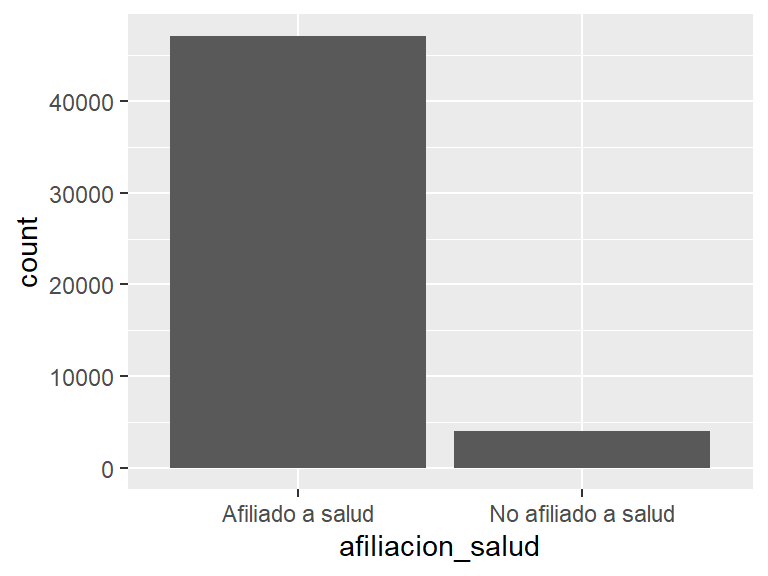

## afiliacion_pensiones

*Tipo de sistema previsional al cual está afiliado*

| Feature | Result |
| --- | --- |
| Variable type | factor |
| Number of missing obs. | 0 (0 %) |
| Number of unique values | 3 |
| Mode | “No afiliado a pensiones” |
| Reference category | AFP (Privado) |

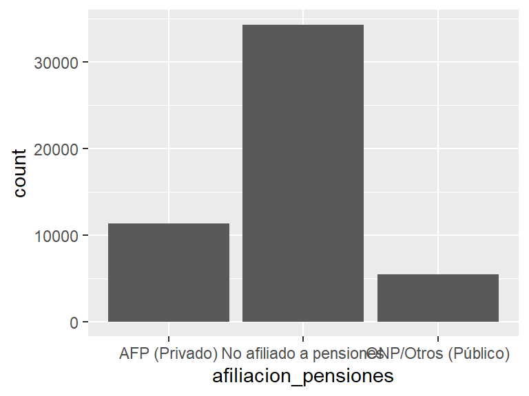

## indice_confianza_simple

*Índice de Confianza Institucional (Promedio Normalizado 0-1)*

| Feature | Result |
| --- | --- |
| Variable type | numeric |
| Number of missing obs. | 190 (0.37 %) |
| Number of unique values | 352 |
| Median | 0 |
| 1st and 3rd quartiles | 0; 0.21 |
| Min. and max. | 0; 1 |

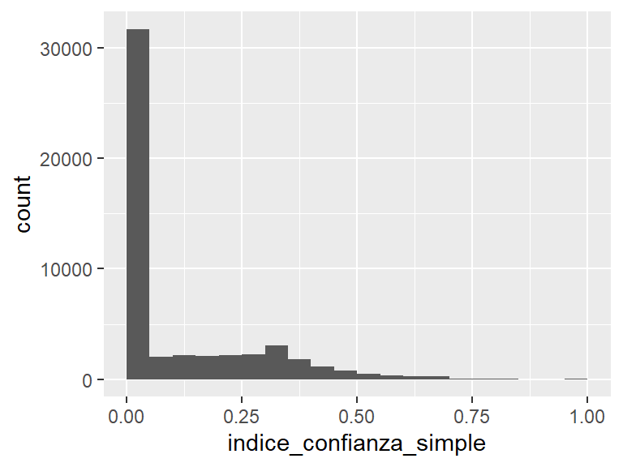

- The following suspected missing value codes enter as regular values: "NaN".

## ingreso_prin_imputado

*Ingreso total mensual proveniente de la -ocupación principal (Soles corrientes) (Fuente: P524A1)*

| Feature | Result |
| --- | --- |
| Variable type | numeric |
| Number of missing obs. | 0 (0 %) |
| Number of unique values | 1141 |
| Median | 885 |
| 1st and 3rd quartiles | 300; 1500 |
| Min. and max. | 5; 24155 |

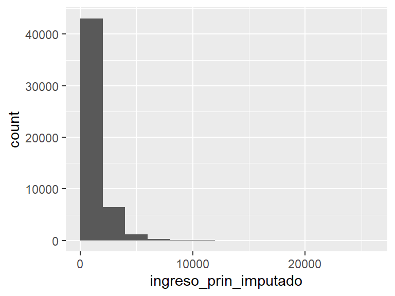

- Note that the following possible outlier values were detected: "4330", "4350", "4360", "4363", "4370", …, "20000", "20800", "21840", "22880", "24155" (198 values omitted).

## tipologia_laboral

*Profundidad de la Informalidad*

| Feature | Result |
| --- | --- |
| Variable type | factor |
| Number of missing obs. | 5864 (11.46 %) |
| Number of unique values | 4 |
| Mode | “4. Informal Absoluto” |
| Reference category | 1. Formal Absoluto |

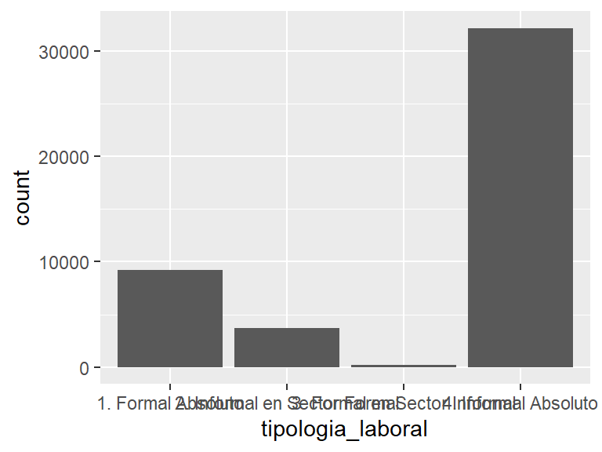